# STAT340 HW08: Prediction I, simple linear regression

Jeffrey Hui

November 2022

## Instructions

Update the “author” and “date” fields in the header and complete the exercises below. Knit the document, and submit **both the HTML and RMD** files to Canvas.

**Due date:** November 10, 2022 at 11:59pm.

```r
# We are including a seed value to make sure that your code runs the same way
# every time we knit this document.
# This will ensure that the random numbers you see are the same ones we see
# if we re-knit your document, and it will ensure that your random numbers don't
# change each time you re-knit.
set.seed(1848340);
```

This homework will review our discussion of prediction from this week’s lectures, focusing on simple and multiple linear regression.

## 1) Catamaran, revisited

Startup pet supply company Catamaran is trying to better understand the spending behavior of its customers. In particular, the company wants to find simple ways to predict how much customers will spend on Catamaran products from their purchases of just one such product: cat litter.

A (sadly, fictional) data set is stored in the file `catamaran.csv`, available from the course webpage [here](https://pages.stat.wisc.edu/~kdlevin/teaching/Fall2022/STAT340/hw/hw08/catamaran.csv) or on Canvas. Download this file and save it in the same directory as your working directory (you can check this directory with `getwd()`). The data frame encoded in this file stores two columns:

1. The column titled `litter` is the amount of cat litter, in pounds, purchased by a customer in the past year (you’ll see in the data that Catamaran sells litter in three-pound increments; no, I don’t think that’s a realistic increment in which to sell cat littler. Fictional data is fun!).
2. The column titled `spending` is the amount of money, in dollars, that a customer has spent on Catamaran products (including cat litter) in the past year.

The following block of code loads the data in this file into a data frame `catamaran`.

```r
setwd('D:\\CODE\\R\\stat340\\hw08')
catamaran <- read.csv('catamaran.csv')
```

## Part a) inspecting the data

Create a scatterplot showing customer spending as a function of how much cat litter they bought. Do you see a linear trend? Based just on looking at the scatterplot, what do you estimate the slope to be (you will not be graded on the accuracy of this estimate– just give a best guess for fun to see how close it is to the estimated model!).

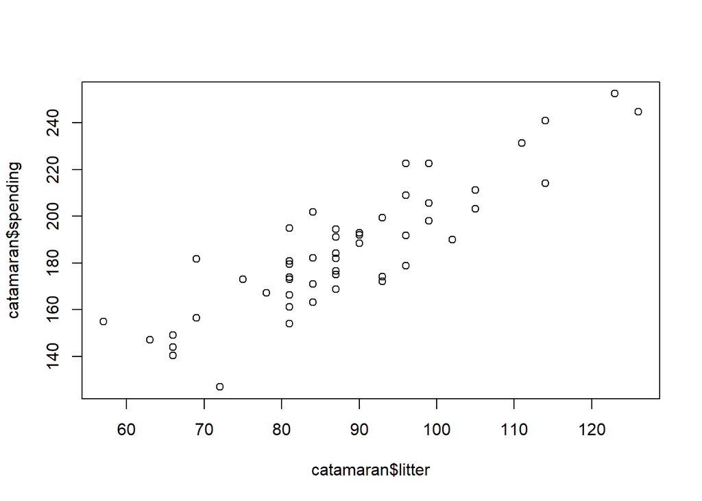

```r
plot(catamaran$litter, catamaran$spending)
```

### Part b) fitting a model

Fit a linear model to the Catamaran data, regressing spending against the amount of litter purchased (and an intercept term).

Store the estimated intercept in a variable called `cat_intercept_hat`, and store the estimated coefficient of `spending` in a variable called `cat_slope_hat`. Don’t forget to use the `unname()` function to strip the labels off of these, ensuring that these two variables just store numbers.

```r
cata_model <- lm(spending ~ 1 + litter, data = catamaran)
cat_intercept_hat <- unname(cata_model$coefficients[1])
cat_slope_hat <- unname(cata_model$coefficients[2])

cat_intercept_hat
```

```
## [1] 44.35549
```

```r
cat_slope_hat
```

```
## [1] 1.596584
```

### Part c) interpreting the model

Based on these estimates, the purchase of one additional pound of cat litter per year is associated with how many more dollars per year spent on Catamaran products?

Base on the estimates, the purchase of one additional pound of cat litter per year is associated with approximately 1.6 more dollars per year spent on Catamaran products.

As we mentioned above, Catamaran sells cat littler in three-pound units. Thus, a more natural question is: the purchase of one additional three-pound unit (i.e., three additional pounds) of cat littler is associated with an increase of how many more dollars per year spent on Catamaran products?

Base on the estimates, the purchase of three additional pound of cat litter per year is associated with approximately 4.8 more dollars per year spent on Catamaran products.

Perhaps a more sane increment in which to sell cat litter would be twenty-pound bags. Based on your estimated coefficients, an additional twenty pounds of cat litter purchased per year is associated with an increase of how many more dollars per year spent on Catamaran products?

### Part d) generating a confidence interval

Of course, Catamaran’s data is noisy, so there is uncertainty in our estimate of the coefficients in our model.

Create a Q-Q plot to verify that the residuals of our model are approximately normal. Do you see anything unusual? You probably won’t– the observation errors in this fake data really are normal. Still, take a look just to be sure; it’s a good habit to always at least briefly check the appropriateness of your model.

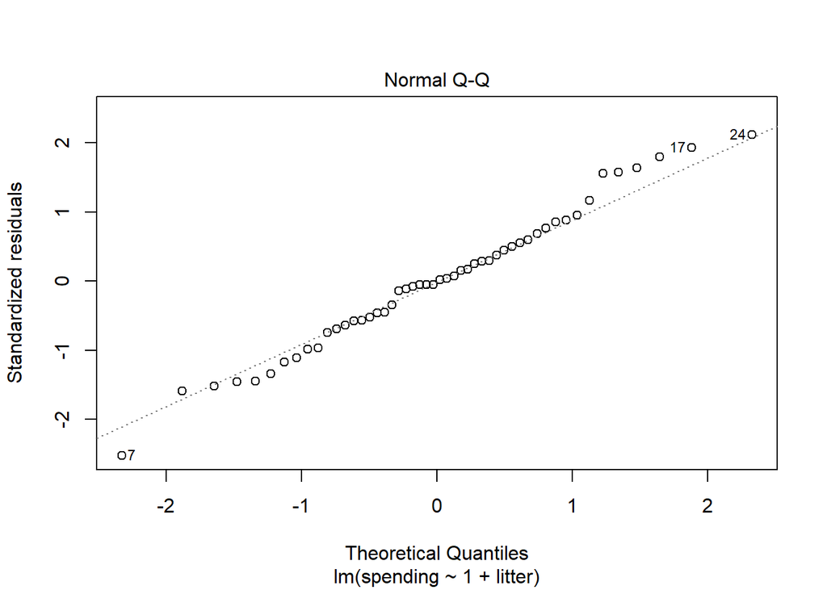

```r
plot(cata_model, which = 2)
```

```r
# There is nothing unusual about the graph, it conforms to the normal assumption.
```

Once you’ve verified that the residuals look reasonable, and hence our normality assumptions are defensible, construct a 95% confidence interval for the coefficient of `litter` in our model.

```r
confint(cata_model, level = 0.95)
```

```
##                 2.5 %    97.5 %
## (Intercept) 21.629927 67.081053
## litter       1.342085  1.851083
```

Based on this confidence interval, should we accept or reject the null hypothesis that $\beta_1=0$ at level $\alpha=0.05$?

Based on the confidence interval, we should reject the null hypothesis that $\beta_1=0$ at level $\alpha=0.05$ since 0 is outside this confidence interval.

Finally, verify your answer by looking at the `summary` output of your model and check that the coefficient is or is not statistically significantly different from zero.

```r
summary(cata_model)
```

```
##
## Call:
## lm(formula = spending ~ 1 + litter, data = catamaran)
##
## Residuals:
##     Min      1Q  Median      3Q     Max
## -32.405  -8.080  -0.167   7.658  27.083
##
## Coefficients:
##             Estimate Std. Error t value Pr(>|t|)
## (Intercept)  44.3555    11.3027   3.924 0.000277 ***
## litter        1.5966     0.1266  12.614  < 2e-16 ***
## ---
## Signif. codes:  0 '***' 0.001 '**' 0.01 '*' 0.05 '.' 0.1 ' ' 1
##
## Residual standard error: 13.14 on 48 degrees of freedom
## Multiple R-squared:  0.7682, Adjusted R-squared:  0.7634
## F-statistic: 159.1 on 1 and 48 DF,  p-value: < 2.2e-16
```

## 2) Understanding the effect of noise

This problem, loosely based on Problem 13 in Chapter 3 of [ISLR](https://www.statlearning.com/), will help to give you an intuition to the role of sample size (i.e., number of observations $n$) and noise level (as captured by the variance $\sigma^2$ of the noise terms $\epsilon_i$).

### Part a) generating linear data

Write a function `generate_linear_data` that takes two arguments: `n` and `sigma2`, in that order, and does the following:

1. Use the `rnorm()` function to create a vector `x`, containing `n` independent observations drawn from a normal distribution with mean $0$ and variance $1$. This will represent our vector of predictors.
2. Use the `rnorm()` function to create a vector, `eps`, containing `n` independent observations drawn from a normal distribution with mean $0$ and variance `sigma2`. These will correspond to the errors in our observed responses.
3. Using `x` and `eps`, construct a vector `y` according to the model
   $$Y = −1 + 0.5X + \epsilon,$$

where $X$ corresponds to entries in our vector `x` and $\epsilon$ corresponds to entries in our vector `eps`.

4. Create a data frame with two columns, `predictors` and `responses` whose entries correspond to the vectors `x` and `y`, respectively. Return this data frame.

You do not need to perform any error checking in this function. You may assume that `n` is a positive integer and `eps` is a positive numeric.

Before writing code, let’s **check your understanding:** What is the length of the vector `y`? What are the values of the intercept $\beta_0$ and slope $\beta_1$ in this linear model?

The length of the vector y is just n. The values of the intercept $\beta_0$ would be -1 and slope $\beta_1$ would be 0.5 in this model. ***

```r
generate_linear_data <- function( n, sigma2 ) {
  x <- rnorm(n, 0, 1)
  eps <- rnorm(n, 0, sd = sqrt(sigma2))
  y <- -1 + 0.5 * x + eps
  return (data.frame(
    predictors=x,
    responses=y
  ))
}
```

### Part b) Plotting data

Use your function from Part (a) to generate 100 samples from the model
$$Y = −1 + 0.5X + \epsilon,$$

with `sigma2` set to $0.25$ and create a scatterplot of that data, showing the responses $Y$ as a function of $X$. You may use either `ggplot2` or R’s built-in plotting utilities.

Examine the point cloud and discuss: Does the data look approximately linear? Does the slope look about right? What about the intercept? **Note:** You **do not** need to fit a model, yet! Just inspect the data!

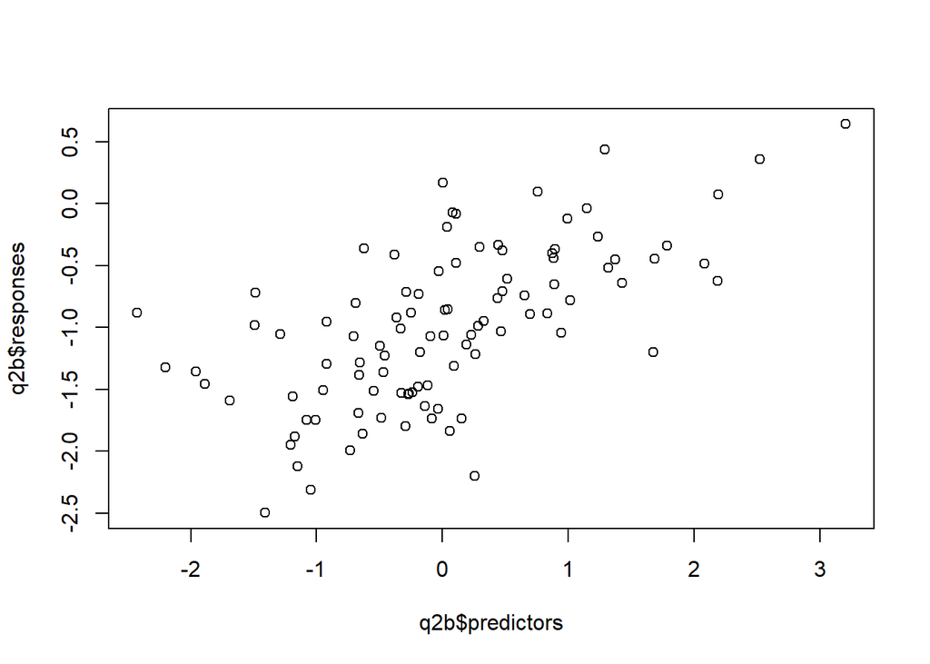

```r
q2b <- generate_linear_data(100, 0.25)
plot(q2b$predictors, q2b$responses)
```

The data look approximately linear, the slope look about right, and the intercept seems to be correct.

### Part c) the effect of noise

Now, generate 100 data points again, as in part (b), but increase the noise level (i.e., the variance of the observation errors $\epsilon$) to $1$. That is, set `sigma2` to `1`. Plot the data again, and compare to the previous plot. What do you observe?

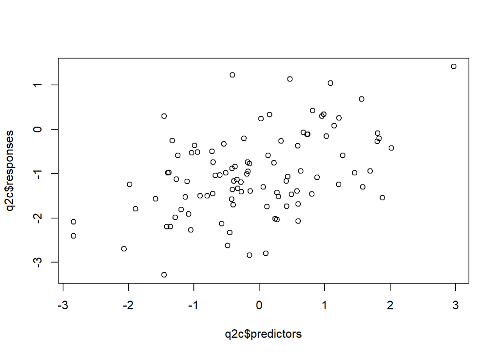

```r
q2c <- generate_linear_data(100, 1)
plot(q2c$predictors, q2c$responses)
```

The data look less linear and random, it is hard to see a trend.

Now, try decreasing the noise level (i.e., the variance of the $\epsilon$ terms), down to $\sigma^2 = 0.1$ and create one more plot, again with $n=100$ data points. What do you observe?

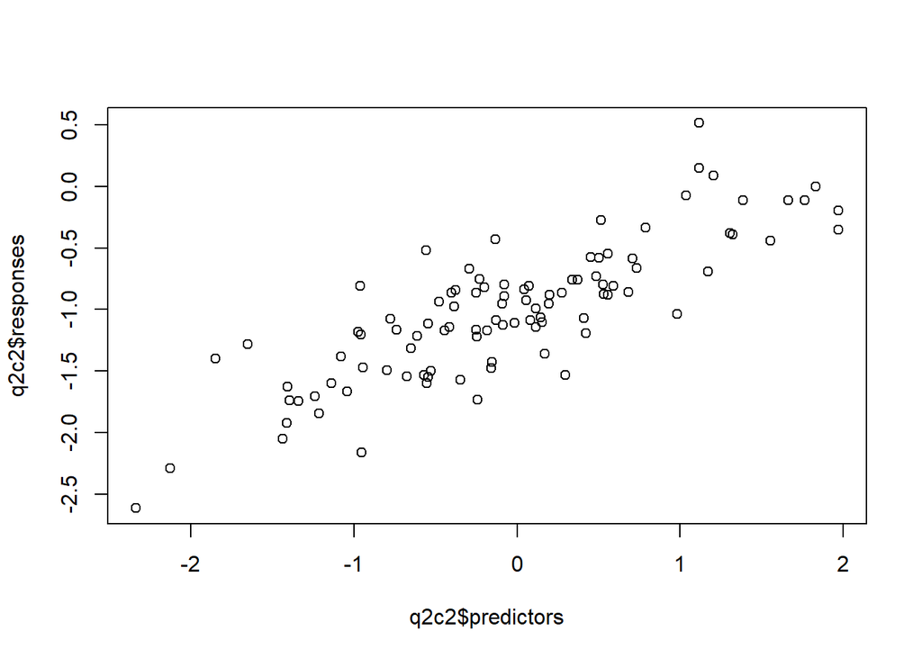

```r
q2c2 <- generate_linear_data(100, 0.1)
plot(q2c2$predictors, q2c2$responses)
```

The data look more linear and shows a strong trend.

### Part d) estimating from synthetic data

Now, let’s investigate how the amount of noise (i.e., the error term variance $\sigma^2$) influences our estimation of the slope $\beta_1$. Hopefully in your plots above you noticed that when the variance $\sigma^2$ is larger, the linear trend in the data is “harder to see”. Perhaps unsurprisingly, but still interestingly, this translates directly into difficulty in estimating the coefficients. When there is more noise in our observations, our estimation of the coefficients suffers.

Let’s investigate this with a simulation. This part of the problem will have you write code to run a single experiment wherein we generate data and try to estimate the slope $\beta_1$. In Part (e) below, we’ll use this single-trial code to run a Monte Carlo simulation that estimates the variance of our estimate $\hat{\beta}_1$. We’ll be able to see how the variance of our estimate (i.e., how close we are on average to the true $\beta_1$) changes as the noise $\sigma^2$ changes.

Write a function `generate_and_estimate` that takes two arguments: a sample size `n` and a variance term `sigma2`, and does the following:

1. Use `generate_linear_data` to generate a collection of `n` observations from a linear model
   $$Y = −1 + 0.5X + \epsilon,$$
   where the noise term $\epsilon$ is normal with variance `sigma2`.
2. Pass this data into `lm()` to fit a model predicting the column `responses` from the column `predictors` and an intercept term.
3. Extract the estimate of the slope from the resulting fitted model object (hint: look at the `coefficients` attribute of the model object or use the function `coef()`). Call this `beta1hat`. **Hint:** don’t forget to use `unname()` to remove the “names” of the coefficients extracted from the model object.
4. Return `beta1hat`.

```r
generate_and_estimate <- function( n, sigma2 ) {
  data <- generate_linear_data(n, sigma2)
  mod <- lm(responses ~ 1 + predictors, data = data)
  beta1hat <- unname(coef(mod)[2])
  return (beta1hat)
}
```

### Part e) estimating variance of an estimator

Now, let’s write code compute a Monte Carlo estimate of the variance of our estimator $\hat{\beta}_1$. Note that this variance is a good way to measure the (average) squared error of our estimator. When this variance is large, it means that our estimate of $\beta_1$ is more uncertain, as we expect to be farther from the true value of $\beta_1$ more often, on average.

Write a function `estimate_beta1hat_variance` that takes three arguments: a number of observations `n`, a variance `sigma2` and a number of Monte Carlo replicates `M`, and does the following:

1. Use `generate_and_estimate` to generate a collection of `n` observations from a linear model
   $$Y = −1 + 0.5X + \epsilon,$$
   where the noise term $\epsilon$ is normal with variance `sigma2`, and estimate $\beta_1$. Call the resulting estimate `beta1hat`.
2. Perform step 1 a total of `M` times, recording the resulting `beta1hat` each time in a vector. That is, perform `M` Monte Carlo iterations of the experiment wherein we generate random data and estimate the slope $\beta_1 = 0.5$, keeping track of our estimate in each Monte Carlo replicate.
3. Compute and return the variance of our `M` random `beta1hat` replicates. This is a Monte Carlo estimate of the variance of our estimate $\hat{\beta}_1$. You may use either the corrected or uncorrected sample variance in this calculation.

```r
estimate_beta1hat_variance <- function( n, sigma2, M ) {
  betas <- rep(-1, M)
  for (i in 1:M) {
    betas[i] <- generate_and_estimate(n, sigma2)
  }
  return (var(betas))
}
```

### Part f) effect of noise on estimation accuracy

Use your function from Part (e) to create a plot of the variance (as estimated from 1000 Monte Carlo iterates) of the estimator $\hat{\beta}_1$, as a function of $\sigma^2$, when $n=100$. Use values for $\sigma^2$ ranging from $0.25$ to $4$, inclusive, in increments of $0.25$. You may use either `ggplot2` or the built-in R plotting functions.

**Note:** this simulation make take a few minutes to run, since for each value of $\sigma^2$, we must perform $M=1000$ simulations, and each simulation requires fitting linear regression, which is not free!

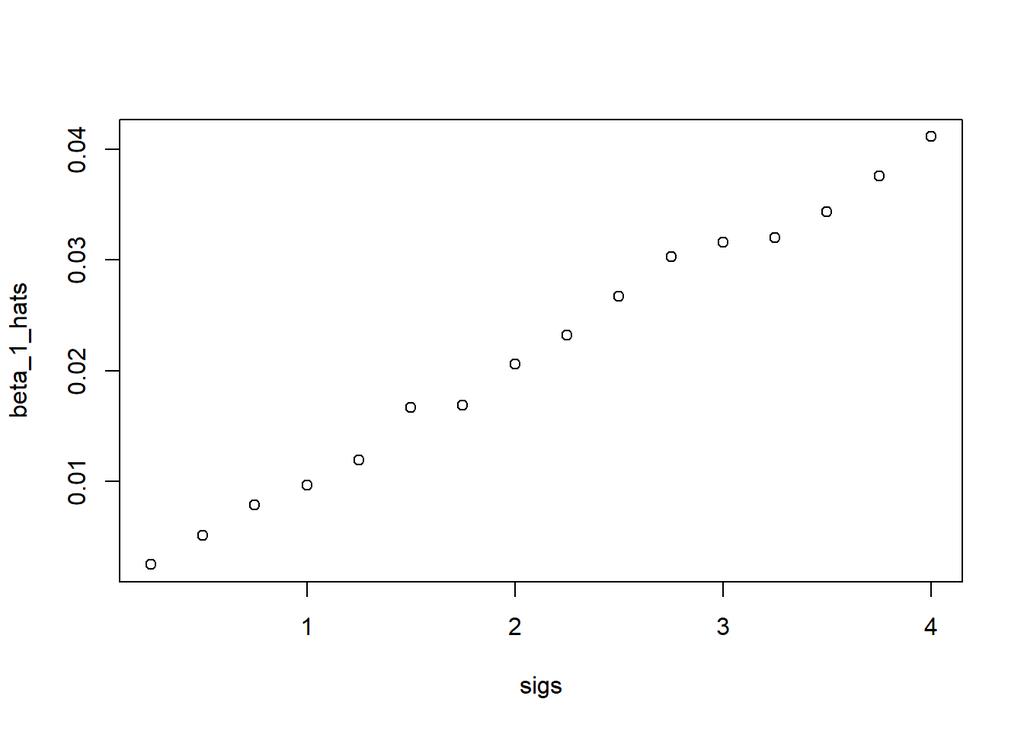

```r
sigs <- seq(from = 0.25, to = 4, by = 0.25)
beta_1_hats <- rep(-1, length(sigs))
for (i in seq_along(sigs)) {
  beta_1_hats[i] <- estimate_beta1hat_variance(100, sigs[i], 1000)
}

plot(sigs, beta_1_hats)
```

Based on your plot, how does it look like the variance of our estimator $\hat{\beta}_1$ behaves as a function of the observation error variance $\sigma^2$?

If you look up the variance of $\hat{\beta}_1$ in a mathematical statistics textbook, you will find that
$$\operatorname{Var} \hat{\beta}_1
=
\frac{ \sigma^2 }{ \sum_{i=1}^n (x_i - \bar{x})^2 }.$$

Does this agree with your plot above?

Yes, the formula agree with my plot since if sigma square gets larger, the variance for $\hat{\beta}_1$ also becomes larger.